# How to: Weather Radials

Joshua Kunst

Wed Mar 23 23:04:52 2016

TLDR: Creating weather radials with highcarter and ggplot2.

I was surfing by the deep seas of the web and I found the *Brice Pierre de la Briere*’s [blocks](http://bl.ocks.org/bricedev) and I saw the *weather radials* which originally are [poster collection](http://weather-radials.com/). Brice use D3 and he used D3 very well and I love D3 but I’m in a rookie level to do something like him. **D3 is not for everybody** and surely not for me, I would love to lear more but family, work and R has priority over D3 so how can I do something like that. Well I have highcarter. So let’s try.

We’ll use the same data as Brice (https://www.wunderground.com/).

```r
df <- read_csv("http://bl.ocks.org/bricedev/raw/458a01917183d98dff3c/sf.csv")

df[1:4, 1:4]
```

```
## Source: local data frame [4 x 4]
##
##         date Max TemperatureC Mean TemperatureC Min TemperatureC
##       (date)            (int)             (int)            (int)
## 1 2014-01-01               13                 9                5
## 2 2014-01-02               17                12                6
## 3 2014-01-03               18                12                7
## 4 2014-01-04               19                13                6
```

```r
names(df) <- names(df) %>%
  str_to_lower() %>%
  str_replace("\\s+", "_")

df <- df %>%
  mutate(id = seq(nrow(df)),
         date2 = as.Date(ymd(date)),
         tmstmp = datetime_to_timestamp(date2),
         month = month(ymd(date)))

dsmax <- df %>%
  select(x = tmstmp,
         y = max_temperaturec) %>%
  list.parse3()

dsmin <- df %>%
  select(x = tmstmp, y = min_temperaturec) %>%
  list.parse3()
```

## First try

Here we test and chart the data in the most simple way. A line time.

```r
hc <- highchart() %>%
  hc_chart(
    type = "line"
    ) %>%
  hc_xAxis(
    type = "datetime",
    tickInterval = 30 * 24 * 3600 * 1000,
    labels = list(format = "{value: %b}")
  ) %>%
  hc_yAxis(
    min = 0,
    labels = list(format = "{value}°C")
  ) %>%
  hc_add_series(
    data = dsmax, name = "max"
  ) %>%
  hc_add_series(
    data = dsmin, name = "min"
    ) %>%
  hc_add_theme(
    hc_theme_smpl()
    )

hc
```

[interactive chart not shown]

Everything seem fine.

## Second Step

We’ change the type to column, stack and see what is the result

```r
hc <- hc %>%
  hc_chart(
    type = "column"
    ) %>%
  hc_plotOptions(
    series = list(
      stacking = "normal"
    )
  )

hc
```

[interactive chart not shown]

Not so close.

## Final Step

If you see the previous chart we stacked so we sum the min and max and the data don’t reflect the value (min,max) what we want. So we need to create the difference between the max and min, and plot them with the min value and hiding using a transparent color.

```r
dsmax <- df %>%
  mutate(color = colorize_vector(mean_temperaturec, "A"),
         y = max_temperaturec - min_temperaturec) %>%
  select(x = tmstmp,
         y,
         name = date,
         color,
         mean = mean_temperaturec,
         max = max_temperaturec,
         min = min_temperaturec) %>%
  list.parse3()


# Some tooltips to make it a little *intercative*
x <- c("Min", "Mean", "Max")
y <- sprintf("{point.%s}", tolower(x))
tltip <- tooltip_table(x, y)

hc <- highchart() %>%
  hc_chart(
    type = "column",
    polar = TRUE
  ) %>%
  hc_plotOptions(
    series = list(
      stacking = "normal",
      showInLegend = FALSE
    )
  ) %>%
  hc_xAxis(
    gridLineWidth = 0.5,
    type = "datetime",
    tickInterval = 30 * 24 * 3600 * 1000,
    labels = list(format = "{value: %b}")
  ) %>%
  hc_yAxis(
    max = 30,
    min = -10,
    labels = list(format = "{value}°C"),
    showFirstLabel = FALSE
    ) %>%
  hc_add_series(
    data = dsmax
  ) %>%
  hc_add_series(
    data = dsmin,
    color = "transparent",
    enableMouseTracking = FALSE
  ) %>%
  hc_add_theme(
    hc_theme_smpl()
  ) %>%
  hc_tooltip(
    useHTML = TRUE,
    headerFormat = as.character(tags$small("{point.x:%d %B, %Y}")),
    pointFormat = tltip
  )

hc
```

[interactive chart not shown]

Yay :D! A beautiful chart same as the d3 version and only using R. So sweet!

I’m happy with the result. This is not a standar chart but is a king of *artistic*. What do you think? Any other examples to test this type of chart?

## Bonus Track: ggplot2 version

It’s *really really* easy to do this type of chart in ggplot2 using `geom_linerange` and `geom_polar`:

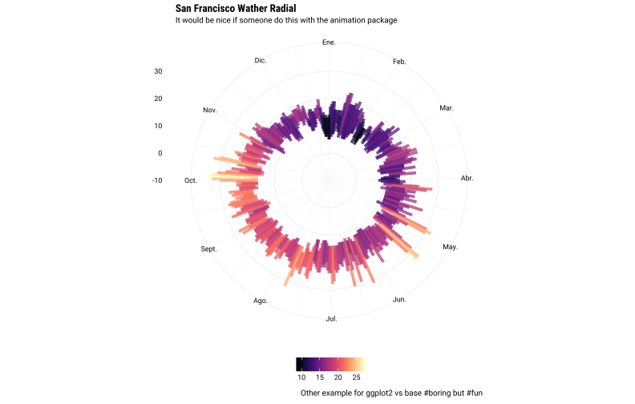

```r
library("ggplot2")
library("viridis")
library("scales")

ggplot(df, aes(date2,
               ymin = min_temperaturec,
               ymax = max_temperaturec,
               color = mean_temperaturec)) +
  geom_linerange(size = 1.3, alpha = 0.75) +
  scale_color_viridis(NULL, option = "A") +
  scale_x_date(labels = date_format("%b"), breaks = date_breaks("month")) +
  ylim(-10, 35) +
  labs(title = "San Francisco Wather Radial",
       subtitle = "It would be nice if someone do this with the animation package",
       caption = "Other example for ggplot2 vs base #boring but #fun",
       x = NULL, y = NULL) +
  coord_polar() +
  theme_jbk() +
  theme(legend.position = "bottom")
```

Nice!

Searching I found someone do [this](https://www.quora.com/R-programming-language/What-is-the-most-elegant-plot-you-have-made-using-ggplot2):

> Always exist someone who did what you did before you.

At least I share the code! :D.